# 新型冠状病毒肺炎疫情控制策略研究: 效率评估及建议

victor

2020/3/30

## 1.疫情控制:拐点、流行时间跨度、最终规模及复工风险评估

### 1.1受控状态及拐点

1.基本再生数（Basic Reproduction Number, $R_0$）：没有干预的情况下，在一个是全部是易感人的环境中，平均一个患者能够传染的人数。  
2.有效再生数（Effective Reproduction Number, $Reff$）：$t$ 时刻开始出现症状的一个患者平均能够传染的人数，一般以天为单位。（2020年2月5日， $Reff=0.91<1$）  
3.确诊灰度（grey degree of diagnosis, $GDD$）：实际报道的患 者总数与本文模型给出的须报道的患者总数 $R(t)$ 的比值。（2020年2月5日，$GDD=0.0$）  
4.拐点：病例曲线继续上升，病例增长速度降低。（2020年2月7日理论拐点出现）

### 1.2流行时间跨度、最终规模及复工风险评估

1.图1（左上）： $vEff$、$sEff$ 和 $iEff$ 分别表示疫苗的效率、对易染源和对传染源的控制效率。 而 $ctrEff$ 则是这些效率的综合结果；红线：有效再生数的上界估计；灰线：确诊灰度。  
2.图 1（右上）： $E$、$I$、$δR$ 和 $Iso$ 分别表示当时处于潜伏态、感染态、恢复态和隔离态的患者数。  
3.图 1（下）： $F$、$G$ 和 $R$ 分别表示从疫情起点到某个时间 $t$ 的处于潜伏态、感染态和恢复态的个 体总数。蓝线是模型给出的确诊患者理论值 (总数)，黑线是实际公布的确诊患者总数。 希腊字母表示 流行病学上重要的参数 (平均潜伏期、平均传染期及它们的 95% 和 99% 的置信区间值， 基本再生数 $R_0$, 非典型患者占比 $θ$ ) 以及相关的其他模型参数。此外，Seed Size 是零号患者的数目，End Size 是到 疫情结束的最终规模。

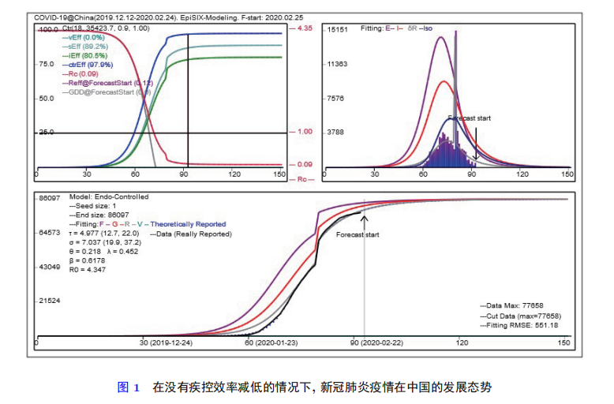

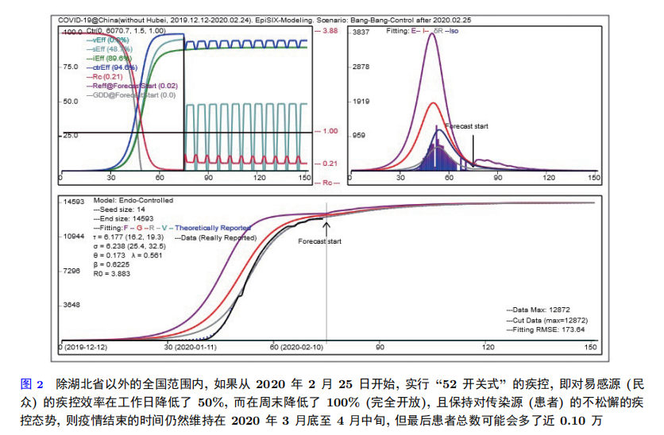

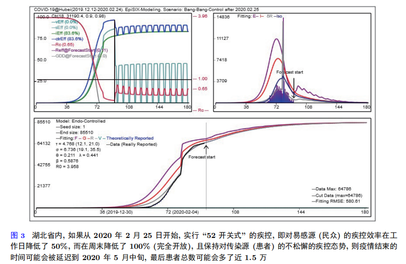

## 2卷积积分模型

### 2.1卷积积分的定义

设有两个函数$f_1(t)$和$f_2(t)$,积分

$f(t)=\int_{-\infty}^{\infty}{f_1(\tau)f_2(t-\tau)}{d\tau}$

称为$f_1(t)$和$f_2(t)$的卷积积分，简称积分，记作

$f(t)=f_1(t)*f_2(t)$或$f(t)={f_1(t)}\bigotimes{f_2(t)}$

其中$t$是指观察响应的时刻，是积分的参变量；$\tau$是指信号作用的时刻，是积分变量.

利用卷积分可以求解系统的零状态响应.

### 2.2完全转移模式: 卷积积分模型

考虑群体中的个体状态转移,即一个个体要历经两种紧接相续的状态,先状态*X*后状态*Y*,且从状态*X* 到状态*Y*的转移是完全的.也就是说,群体中的个体只要进入状态*X*,那么它必然在以后的某个时间点进入到状态*Y*.

### 2.3 一般概率转移模式

为描述转移过程*X*→*Y*,令$X(t)$(相应地,$Y(t)$)是群体中的个体处于状态*X*(相应地,状态*Y*)从开始点$t_0= 0$直至某个时间点$t>0$的累积总数.显然,

*X*和*Y*均为递增函数.

**转移概率** 假定一个恰在时间点 s 进入状态*X*的个体,在后来的时间点${t}\geq{s}$正好进入状态*Y*的概率是$P(t − s)$, 或等价地, 此个体在后来的时间点*t*仍然处于状态*X*的概率是$1 − P(t − s)$.进一步假设这个转移过程*X*→*Y*是齐性, 而且服从于一个累积分布函数 (cumulative distribution function,CDF) *P*:$\mathbb{R}_+{\to}[0, 1]$, 其满足

$P(0)=0$,$\displaystyle \lim_{t\to \infty}P(t)=1$,$\mu:=\int_{0}^{\infty}{(1-P(t))}{dt}<\infty$

其中$\mu=\int_{0}^{\infty}{(1-P(t))}{dt}$为$X\to Y$的平均转移时间,并将这个转移过程记作$X \displaystyle \to^{P}{Y}$.一般地,$\mu$叫作*P*的期望值.显然, 函数 *X*与*Y*可以通过转移概率建立联系, 下面导出二者的关系.

**函数*X*与*Y*的关系** 对给定t > 0, 将区间[0, t]分成n+1个等距的子区间

$\lbrace {\Delta_i:}={[t_i,t_{i+1}]:{0 \leq i\leq n}}\rbrace$,$t_i:=i\Delta t$,$\Delta t=\frac{t}{n-1}$

考虑$\Delta_i=[t_i,t_{i+1}]$.显然有下面的等式:

$X(t_{i+1})-X(t_i)=在\Delta_i时段里进入X 态的个体总数$.

因此，

$(X(t_{i+1})-X(t_i))\times P(t-t_i) \approx上述处于 X 态的成员将在未来的时间点 t 进入 Y 态的个体数$.

另外，那些在起始点0就处于*X*态的成员(数量为$X(0)$), 在经历了*t*单位时间后将进入*Y*态的部分, 数量值是 $X(0)P(t)$. 故有

$Y(t)\approx X(0)P(t)+\displaystyle \sum_i(X(t_{i+1})-X(t_i))\times P(t-t_i)$

$\approx X(0)P(t)+\displaystyle \sum_iX^{'}(t_i)\Delta t\times P(t-t_i)$

$=X(0)P(t)+\int_0^tX^{'}(s)P(t-s){ds}$,$当\Delta t\to 0时$.

因此，

$Y(t)=X(0)P(t)+\int_0^tP(t-s)X^{'}(s){ds}$.

通过分部积分并注意到$P(0)=0$，上式可等价地写成

$Y(t)=\int_0^tP^{'}(t-s)X(s){ds}$.

### 2.4一般时间相关的概率转移

一般地, 若转移概率*P*是时间相关的, 则相应的卷积模型具有如下表达:

$Y(t)=X(0)P(0,t)+\int_0^tX^{'}(s)P(s,t-s){ds}$ $(t\geq 0)$

## **3. SEIR模型**

考虑某种传染性疾病在人群中的传播, 在任何时刻, 每一个体都处于如下 4 种状态之一:  
(1)易感态(susceptible, S), 即个体处于病源的传染范围内, 是高危人群;  
(2)潜伏态(exposed, E), 即个体已被病源感染, 但还没有发病;  
(3)传染态(infectious, I), 即个体已经发病, 具传染性, 症状可能因个体而异;  
(4)移除态(recovered/removed, R; 或称为康净态),即个体或康复, 或因被隔离或死亡等原因而 处于一种无传染性的净置状态.如果是康复, 康复者未必能获得对该病毒的完全免疫力, 所以, 这些个 体可能再次处于病源的辐射范围内, 即 R → S.  
令F(t)、G(t)、R(t)分别是在时间段[0,t]里已处于潜伏态、传染态和康净态的个体累积总数,则

$$E(t):=F(t)-G(t), I(t):=G(t)-R(t)\tag{3.1}$$

是在时间点 t 时处于潜伏态和传染态的个体数, 其相应的初始条件是

$$F(0) \geq 0, G(0)=0, R(0)=0\tag{3.2}$$

根据我们先前的工作，可建立关于不同状态转移S → E →I → R 关系:

$$F'(t)=r(t) \cdot (G(t)-R(t)) 　　　 (S → E),\tag{3.3}$$
$$G(t)=\int^{t}_{0}{F(t-s)W'(s)ds} 　　　(E → I),\tag{3.4}$$
$$R(t)=\int^{t}_{0}{G'(s)A(s,t-s)ds}　　(I → R),\tag{3.5}$$

这里用到了上一节所给的积分模型方程, 其中(3.4)和(3.5)刻画 E → I 和 I → R 这两个转移过 程, 而方程 (3.3) 描述转移过程 S → E, 另外,  
(1)r(t)是非负的有界函数, 它表示在 t 时刻, 单位时间里每个传染者所具有的平均传染率(mean infection rate per unit time per active infective), 称为即时平均传染率.一般地, r(t) 的值依赖于控制效率.  
(2)W(t) 是一个潜伏患者在被感染 t 单位时间后成为传染者的概率.故W是非减函数, W(0) = 0,且当t → $\infty$ 时，W(t) → 1.  
(3)A(t,s)是一个恰好在时刻 t 成为传染者的个体,在经过 s 单位时间后进入恢复态的概率.故对于任意固定的 t，A(t, s) 是 s 的非减函数,且当s → $\infty$ 时,A(t, s) → 1.一般地, A(t, s) 的值依赖于控制效率.  
下面给出传染病动力学模型最基本量, 即有效再生数的计算式:

$$R_{eff}(t):= \int^{\infty}_{0}{r(t+s)(1-A(t,s))ds}　　(t \geq 0),\tag{3.6}$$

它代表在疾病传播过程中, 在时间 t 的一个染病患者在其病程内平均传染的患者数, 它是一个随时间 变化的量, 也是病毒传播是否能够维持的指标.
$$G(t)=F(0)W(t)+\int^{t}_{0}{F'(s)W(t-s)ds}$$
$$G(t)=\int^{t}_{0}{W(t-s)d(F(s)}$$
$$G(t)=-\int^{t}_{0}{F(s)W'(t-s)(-1)d(s)}$$
令u=t-s,则
$$G(t)=\int^{0}_{t}{F(t-u)W'(u)d(t-u)}$$
$$G(t)=\int^{t}_{0}{F(t-u)W'(u)d(u)}$$
$$G(t)=\int^{t}_{0}{F(t-s)W'(s)ds} 　　(E → I)$$

## 4.实施疾控下r和A的表达

这部分的基本任务是将控制变量$(u_S,u_I)$镶入到$r$和$A$的构造里，简化变型，进行实施疾控下的$r$和$A$的表达。

对于建模，首先需要回顾如下4个基本的流行病学上的参数：
$$\begin{align}
β&=内在的每单位时间每个活跃的传染者的平均传染率\\
τ&=平均潜伏期\\
σ&=平均传染期\\
θ&=非典型患者的占比.
\end{align}$$
由此可知，基本再生数为$R_0=β*σ$，
$$\begin{align}
τ=&\int_0^{\infty}(1-W(t)) d t\\
σ=&\int_0^{\infty}(1-A(0,t)) d t
\end{align}$$
关于控制变量$(u_S,u_I)$的意义，定义如下：
$$\begin{align}
1-u_S(t,R(t))&=\frac{受控的易感染者在t时的感染率}{无受控状态下的易感染者的感染率}\\
1-u_I(t,R(t))&=\frac{受控的传染者在t时的传染率}{无受控状态下的传染者的传染率}
\end{align}$$
简要地，这两个控制变量的意义是
$$\begin{align}
u_S(t,R(t)):减低感染率\\
u_I(t,R(t)):减低传染率
\end{align}$$
$u_S$和$u_I$在这里都写成了依赖于康净者$R(t)$的函数，是为了描述“基于报告的患者总数提升疾控力度”这种疾控响应模式。假定函数$u_S$和$u_I$均是$Lebesgue$可测的。$Lebesgue$可测的一个定义是内外逼近，即内测度等于外测度，内测度是指包含在$B$中的所有闭集之测度的上确界，外侧度是包含$B$的所有开集之测度的下确界。这里的$B$是开集，是指集合$B$中任意一点都能取到一个邻域包含于$B$中。

在以上框架下，我们相应地将$r$和$A$写成$u=(u_S,u_I)$的泛函，有
$$\begin{align}
r(u_S)(t)&=β(1-u_S(t,R(t)))\\
A(u_I)(t,s)&=θA_a(u_I)(t,s)+(1-θ)A_b(u_I)(t,s)
\end{align}$$
其中，
$$\begin{align}
A_a(u_I)(t,s)&=1-(1-ϱu_I(t,R(t)))(1-A^a(s))\\
A_b(u_I)(t,s)&=1-(1-u_I(t,R(t)))(1-A^b(s))
\end{align}$$
这里的常数$ϱ \in (0,1)$，反映了控制效率在“非典型传染者” 上的减弱。 $A^a$是子群“非典型传染者”的内在的康净概率函数，$A^b$是“典型传染者”的内在的康净概率函数，
$$\begin{align}
σ_a&=\int_0^{\infty}(1-A^a(t)) d t\\
σ_b&=\int_0^{\infty}(1-A^b(t)) d t
\end{align}$$
一般地，$σ_a\geqσ_b$，$θσ_a+(1-θ)σ_b=σ$，且有
$$\begin{align}
A_1(u_I)(t,s)=1-A(u_I)(t,s)=Y(s)-u_I(t,R(t))Z(s)
\end{align}$$
其中，
$$\begin{align}
Y(s)&=θ(1-A^a(s))+(1-θ)(1-A^b(s))\\
Z(s)&=ϱθ(1-A^a(s))+(1-θ)(1-A^b(s))
\end{align}$$
函数$Y$和$Z$均是非增的，$Z\leq Y$且有
$$\begin{align}
\int_0^{\infty}Y(t)d t&=σ\\
\int_0^{\infty}Z(t)d t&=σ-(1-ϱ)θσ_a\\
\displaystyle\lim_{s\rightarrow\infty}Y(s)&=0=\displaystyle\lim_{s\rightarrow\infty}Z(s)
\end{align}$$

## 5.程序EpiSIX的架构及数值拟合方法

为了实现数值化， 我们将模型转化成积分模型：
$$\begin{align}
F(t)&=F(0)+\int_0^{t}r(u_S)(s)\cdot(G(s)-R(s)) d s,(S \rightarrow E)\\
G(t)&=\int_0^{t}F(t-s)W'(s) d s,(E\rightarrow I)\\
R(t)&=\int_0^{t}G'(s)A(u_I)(s,t-s) d s,(I\rightarrow R)
\end{align}$$

### 5.1 控制效率函数$u_S$和$u_I$的构造

这里只涉及“基于报道的患者总数提升疾控力度”这种疾控响应模式。对于一般形式下控制效率函数的构造，在控制没有受到干扰的情况下，取
$$\begin{align}
u(t)=min\lbrace q,1-exp(-(\frac{R(t)}{m})^p)\rbrace,(t\geq0)
\end{align}$$
其中$q\in [0,1]$，$p$和$m$均为常数，$q$可以用来测量疾控方可能到达的最高疾控力度。$R(t)$ 是从疫情开始$t = 0$ 至某个时间点$t $恢复者的总数， 它与报道的患者总数构成一种同增关系。这里$u(t)$相当于“类$Weibull$分布”。

这里可以看一下$Weibull$分布，
$$f(x;\lambda,k)=\begin{cases}
\frac{k}{\lambda}(\frac{x}{\lambda})^ {(k-1)} exp(-(\frac{x}{\lambda})^k) , & x \geq 0\\
0, & x<0
\end{cases}$$
其中，$x$是随机变量，$\lambda>0$是比例参数，$k>0$是形状参数。当$k=1$时是指数分布。

在出现控制受到干扰的情况下， 假设在某个时间点$t_1>0$之后，有两个时间子集$\Delta_1$和$\Delta_2$，$\Delta_1\cup\Delta_2=[t_1,\infty)$，使得当$t \in \Delta_1$时， 无扰下的控制效率$u(t)$有一个减弱，度为$1-a \in [0, 1]$；而在当$t \in \Delta_2$时， 无扰下的控制效率$u(t)$ 可能也有一个减弱，度为$1-b \in [0, 1]$。 最后，令

$$\widetilde{u}(t)=\begin{cases}
u(t), & t < t_1\\
a\times u(t), & t \in \Delta_1\\
b\times u(t), & t \in \Delta_2
\end{cases}$$

通过适当选取子集$\Delta_1$和$\Delta_2$以及参数$a, b\in [0, 1]$来模拟2020年2月10日复工潮可能带来的对疫情的影响。